# Using InSituDiff

Patrick Danaher

2024-09-10

## Introduction to InSituDiff

InSituDiff is an algorithm for exploratory analysis of single cell spatial transcriptomics data, e.g. CosMx. It is designed for experiments where diseased tissues/regions are compared to controls.

InSituDiff seeks to measure how cellular neighborhoods in diseased tissues are perturbed from control neighborhoods. For every cell in disease tissues, InSituDiff finds the cell in a control tissue with the most similar cellular neighborhood. It then contrasts the expression profile in the target cell’s neighborhood with the expression profile in the matching control neighborhood. The resulting differences, or perturbations, are a powerful view for exploratory data analysis.

InSituDiff provides tools for:

1. Identifying highly perturbed genes
2. Finding clusters of genes whose perturbations have similar spatial patterns
3. Spatial clustering, i.e. splitting tissues into spatial domains with distinct perturbation patters.

## Design

Neighborhood perturbations are properly encoded as a dense matrix over all cells x genes. But in moderately large datasets, this dense matrix can overwhelm the memory of even well-provisioned compute instances.

With the above in mind, InSituDiff is designed to work quickly and with minimal demands on memory. Importantly, it avoids ever calculating the whole matrix of perturbations over all cells x genes. Instead, it derives the data needed to compute perturbations, then for further analysis calculates only the necessary perturbations on the fly.

InSituDiff works by comparing cellular neighborhoods in disease tissues to matching control neighborhoods. This means you can pass it a study’s complete data, regardless of how diverse the disease conditions are, so long as the control tissues are relevant to all disease tissues. If your controls are relevant to different tissues (e.g. healthy liver samples as controls for liver disease and healthy kidney controls for kidney disease), then run your data in batches according to which control tissues are relevant.

## Usage

Start by loading the package and necessary data, a handful of FOVs from kidneys, one with childhood lupus and two controls:

```r
library(InSituDiff)
library(pheatmap)
# load demo data from lupus nephritis:
data(minisle)
# normalize the counts matrix (InSituDiff is best run on normalized data):
normconstants <- pmax(Matrix::rowSums(minisle$counts), 20)
norm_factors <- Matrix::Diagonal(x = 1 / normconstants)
minisle$norm <- norm_factors %*% minisle$counts * mean(normconstants)
rownames(minisle$norm) <- rownames(minisle$counts)
```

## Setting up InSituDiff

Now we set ourselves up for calculating perturbation scores by running `initializeISD`. This function defines two mappings needed for perturbation scoring:

1. The cells making up each cell’s neighborhood
2. For each cell, the identify of the control well with the most-similar neighborhood

```r
obj <- initializeISD(
  mat = minisle$norm, # matrix of normalized expression
  xy = minisle$xy, # matrix of xy coordinates
  tissue = minisle$annot$tissue, # vector of cells' tissue IDs
  iscontrol = grepl("control", minisle$annot$tissue),
  k = 50) # define cellular neighborhoods as a cell's 50 nearest neighbors
str(obj)
```

```
## List of 4
##  $ neighbors     :Formal class 'dgCMatrix' [package "Matrix"] with 6 slots
##   .. ..@ i       : int [1:1415550] 1 2 3 4 45 109 1577 1578 1579 1580 ...
##   .. ..@ p       : int [1:28312] 0 52 105 161 217 271 323 364 409 458 ...
##   .. ..@ Dim     : int [1:2] 28311 28311
##   .. ..@ Dimnames:List of 2
##   .. .. ..$ : chr [1:28311] "c_5_10_1" "c_5_10_2" "c_5_10_3" "c_5_10_4" ...
##   .. .. ..$ : chr [1:28311] "c_5_10_1" "c_5_10_2" "c_5_10_3" "c_5_10_4" ...
##   .. ..@ x       : num [1:1415550] 0.0101 0.029 0.0382 0.0459 0.0366 ...
##   .. ..@ factors : list()
##  $ controlmatches: chr [1:28311, 1] "cc_1_4_3085" "cc_1_8_1228" "cc_1_8_1228" "cc_1_8_1228" ...
##   ..- attr(*, "dimnames")=List of 2
##   .. ..$ : chr [1:28311] "c_5_10_1" "c_5_10_2" "c_5_10_3" "c_5_10_4" ...
##   .. ..$ : NULL
##  $ tissue        : chr [1:28311] "SP19_1139_dis" "SP19_1139_dis" "SP19_1139_dis" "SP19_1139_dis" ...
##  $ iscontrol     : logi [1:28311] FALSE FALSE FALSE FALSE FALSE FALSE ...
```

And that’s all we need to start analysis.

## Calculating neighborhood perturbations

Below we’ll show three useful analyses of perturbations we can perform. But first, at any time you like, you can easily compute a matrix of perturbation scores for any cells and genes you like. To get perturbations for all cells and genes, just enter `cells = NULL, genes = NULL`.

*Warning*: for larger datasets, attempting to compute this matrix for all cells and all genes risks overwhelming your R session’s memory.

```r
selectedperturbations <- getPerturbations(
  x = minisle$norm,
  obj = obj,
  cells = rownames(minisle$counts)[minisle$annot$tissue == "SP19_1139"], # only look at one tissue
  genes = c("IGHA1", "FGFR3", "HIF1A", "ACE2", "SAT1"),  # only look at a few genes of interest
  residtype = "log2ratio",  # look at perturbations on the scale of log fold-changes
  eps = 1)
# the result is just dense matrix of perturbation scores over cells x genes:
selectedperturbations[1:5,1:5]
```

```
##                 IGHA1     FGFR3      HIF1A      ACE2       SAT1
## c_5_10_1 -0.022279507 0.5236128 0.26266052 0.5356356 -0.1555109
## c_5_10_2  0.004837366 0.1794484 0.07303612 0.4804071 -0.2636894
## c_5_10_3  0.033525819 0.2775082 0.11361633 0.4501462 -0.2279438
## c_5_10_4  0.033525819 0.2418855 0.14597395 0.5395581 -0.1851453
## c_5_10_5  0.004837366 0.1947532 0.17191899 0.6355393 -0.1309711
```

## Identifying highly perturbed genes

Plotting these scores against each other gives a good sense of how genes are perturbed:

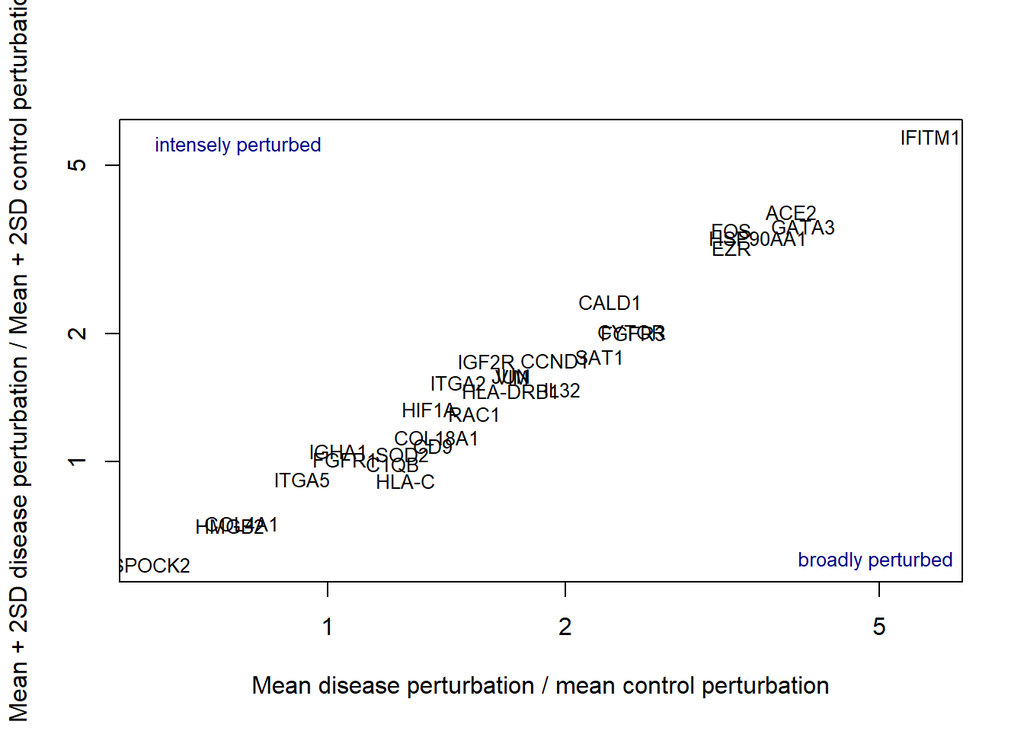

```r
genescores <- summarizeGenePerturbation(
  x = minisle$norm, obj = obj,
  residtype = "log2ratio", plotresults = TRUE, eps = 0.1, subsetsize = 1e5)
```

To get a feel for what these statistics mean, let’s look at a broadly perturbed and an intensely perturbed gene:

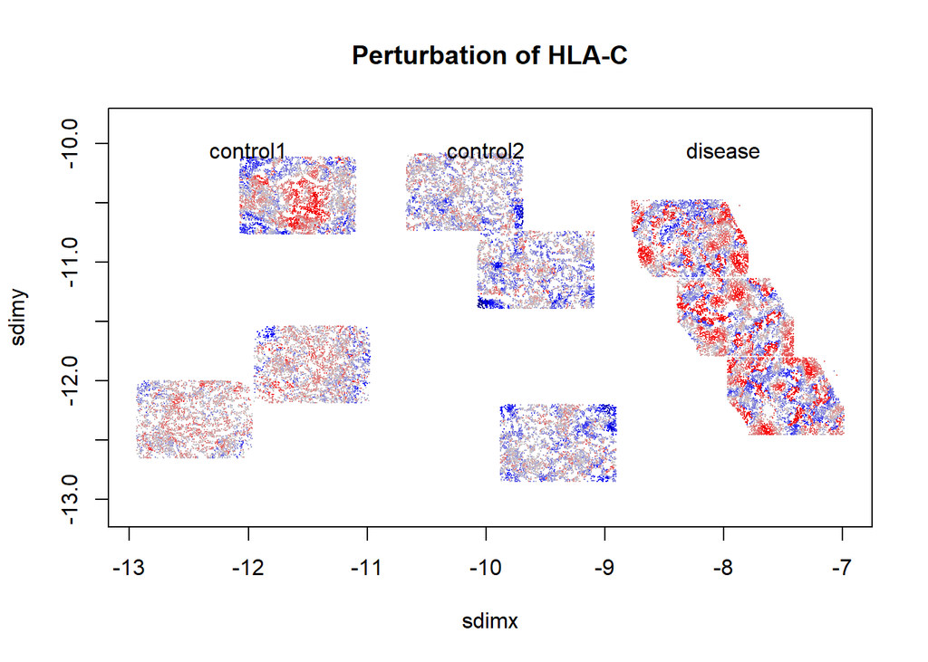

```r
twogenesperturbations <- getPerturbations(
  x = minisle$norm,
  obj = obj,
  cells = NULL, # only look at one tissue
  genes = c("HLA-C", "CYTOR"),  # only look at a few genes of interest
  residtype = "log2ratio",  # look at perturbations on the scale of log fold-changes
  eps = 0.2)
gene = "HLA-C"
plot(minisle$xy, pch = 16, cex = 0.1, asp = 1, main = paste0("Perturbation of ", gene),
     col = colorZeroCentered(twogenesperturbations[, gene], maxquant = 0.999))
text(c(-12, -10, -8), rep(-10.05, 3), c("control1", "control2", "disease"), cex = 1)
```

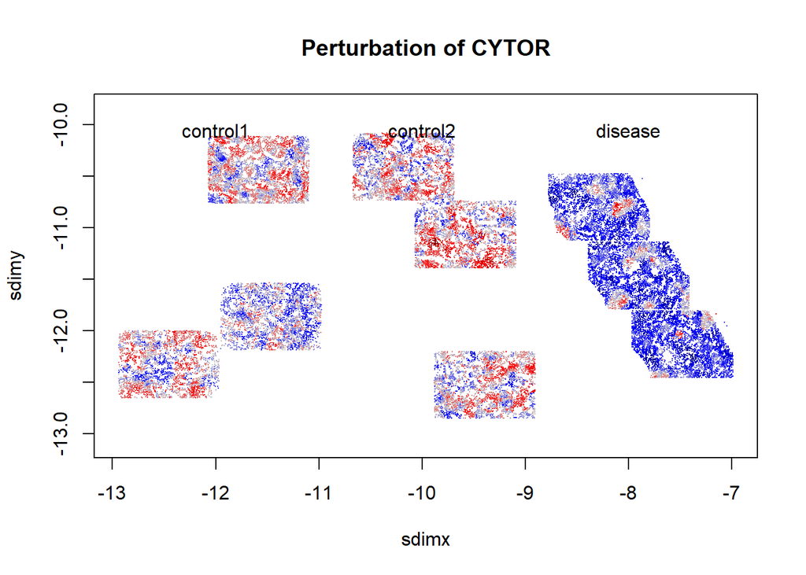

```r
gene = "CYTOR"
plot(minisle$xy, pch = 16, cex = 0.1, asp = 1, main = paste0("Perturbation of ", gene),
     col = colorZeroCentered(twogenesperturbations[, gene], maxquant = 0.999))
text(c(-12, -10, -8), rep(-10.05, 3), c("control1", "control2", "disease"), cex = 1)
```

We might wish to define our own list of highly perturbed genes for downstream analysis. A simple approach to this problem is this:

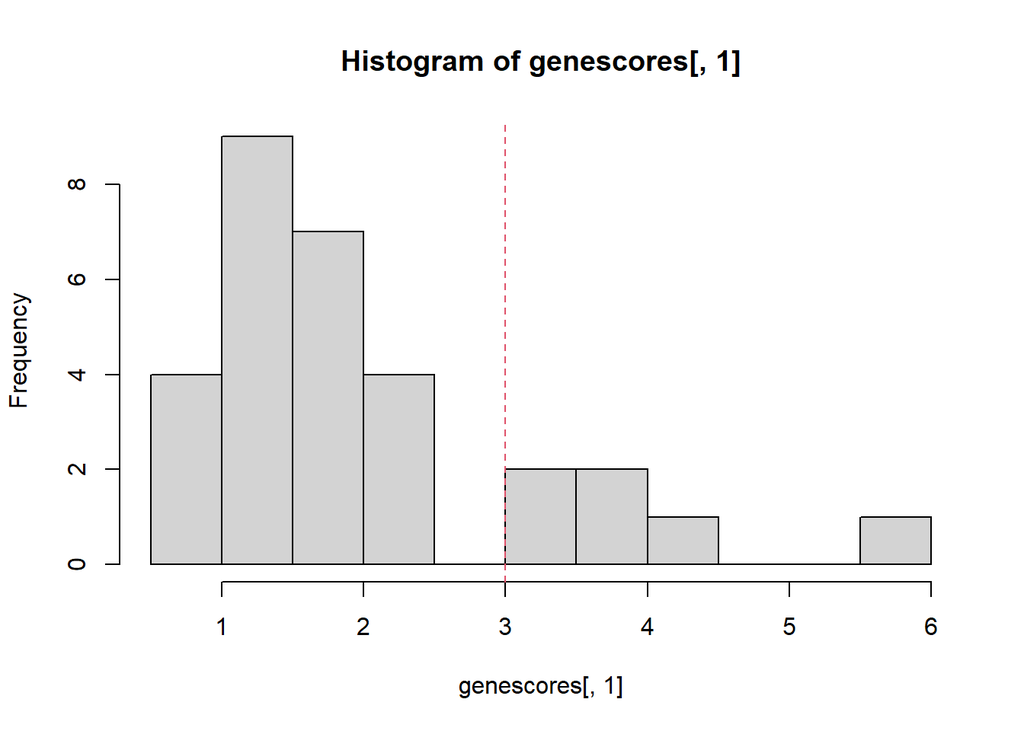

```r
# identify highly perturbed genes:
hist(genescores[,1], breaks = 10)
thresh = 3
abline(v = thresh, col = 2, lty = 2)
```

```r
hpgs <- rownames(genescores)[genescores[, "broadness"] > thresh]
print(paste0("Highly perturbed genes: ", paste0(hpgs, collapse = ", ")))
```

```
## [1] "Highly perturbed genes: ACE2, FOS, HSP90AA1, IFITM1, GATA3, EZR"
```

## Identifying modules of genes with spatially correlated perturbations

We can quickly find clusters of genes whose perturbations have similar spatial distributions as follows:

```r
modules <- buildGeneModules(
  x = minisle$norm, obj = obj,
  genes = NULL,  # subset of genes to use; enter NULL to use all, or "highlyperturbed" to take just the most perturbed genes ("highlyperturbed" is our default and our recommendation for full studies; here we use NULL because our mini dataset has only 30 genes.)
  resolution = 0.02, # control leiden clustering
  corthresh = 0.3, # control the adjacency network used by leiden clustering
  min_module_cor = 0.25, # throw out modules with average cor below this
  subsetsize = 1e5,
  eps = 0.5,
  residtype = "log2ratio")
modules
```

```
## $EZR_HSP90AA1_13
##  [1] "FGFR3"    "ACE2"     "SOD2"     "HSP90AA1" "IFITM1"   "CALD1"
##  [7] "CCND1"    "IL32"     "IGF2R"    "COL18A1"  "HLA-C"    "RAC1"
## [13] "EZR"
##
## $SAT1_HIF1A_7
## [1] "HIF1A"    "SAT1"     "CYTOR"    "HLA-DRB1" "COL4A1"   "VIM"      "ITGA2"
##
## $FOS_GATA3_6
## [1] "IGHA1" "FGFR1" "FOS"   "CD9"   "JUN"   "GATA3"
```

We can explore module perturbations using the same code as for gene perturbations, entering our list of modules in the “genes” argument:

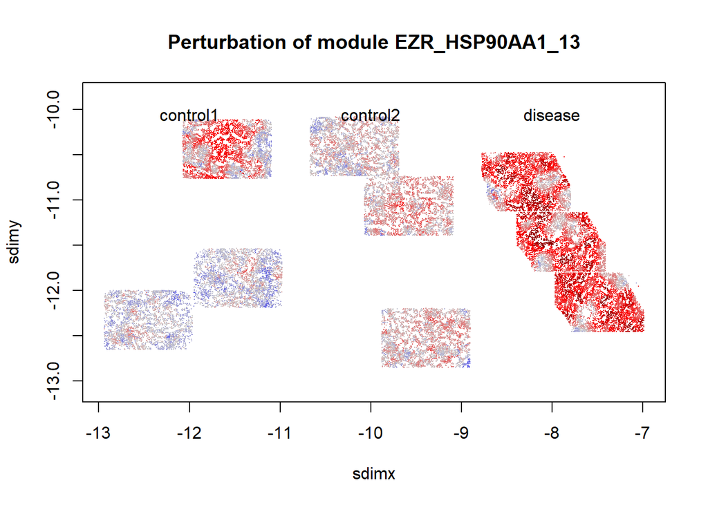

```r
moduleperturbations <- getPerturbations(
  x = minisle$norm,
  obj = obj,
  cells = NULL, # only look at one tissue
  genes = modules[1:2], # arbitrarily plotting the first and second modules
  residtype = "log2ratio",  # look at perturbations on the scale of log fold-changes
  eps = 0.2)

plot(minisle$xy, pch = 16, cex = 0.1, asp = 1,
     main = paste0("Perturbation of module ", colnames(moduleperturbations)[1]),
     col = colorZeroCentered(moduleperturbations[, 1], maxquant = 0.999))
text(c(-12, -10, -8), rep(-10.05, 3), c("control1", "control2", "disease"), cex = 1)
```

## Using perturbation to define spatial domains

Spatial clustering is a large field. We propose that spatial clustering using perturbation scores can be more informative than clustering using simple gene expression. A perturbation matrix derived with `getPerturbations` can be entered into all manner of spatial clustering algorithms. For convenience, InSituDiff provides the below function to perform spatial clustering of perturbation scores. It is designed to be fast and simple.

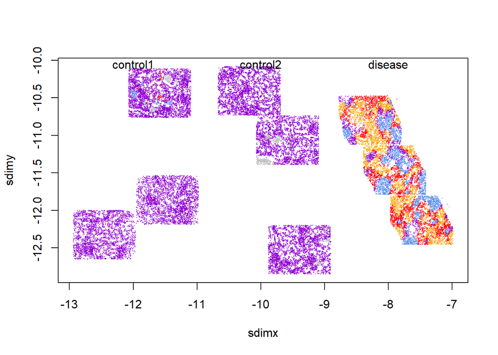

```r
set.seed(0)
res <- clusterPerturbations(x = minisle$norm, obj = obj,
                            cells = NULL,
                            genes = hpgs, # using the highly perturbed genes we defined earlier
                            residtype = "log2ratio",
                            nclust = 6)
plot(minisle$xy, pch = 16, cex = 0.1,
     col = c("grey", "cornflowerblue", "darkviolet", "orange", "red", "forestgreen")[
       as.numeric(as.factor(res$clust))])
text(c(-12, -10, -8), rep(-10.05, 3), c("control1", "control2", "disease"), cex = 1)
```

To understand our results, we might then look at average perturbation of genes within clusters:

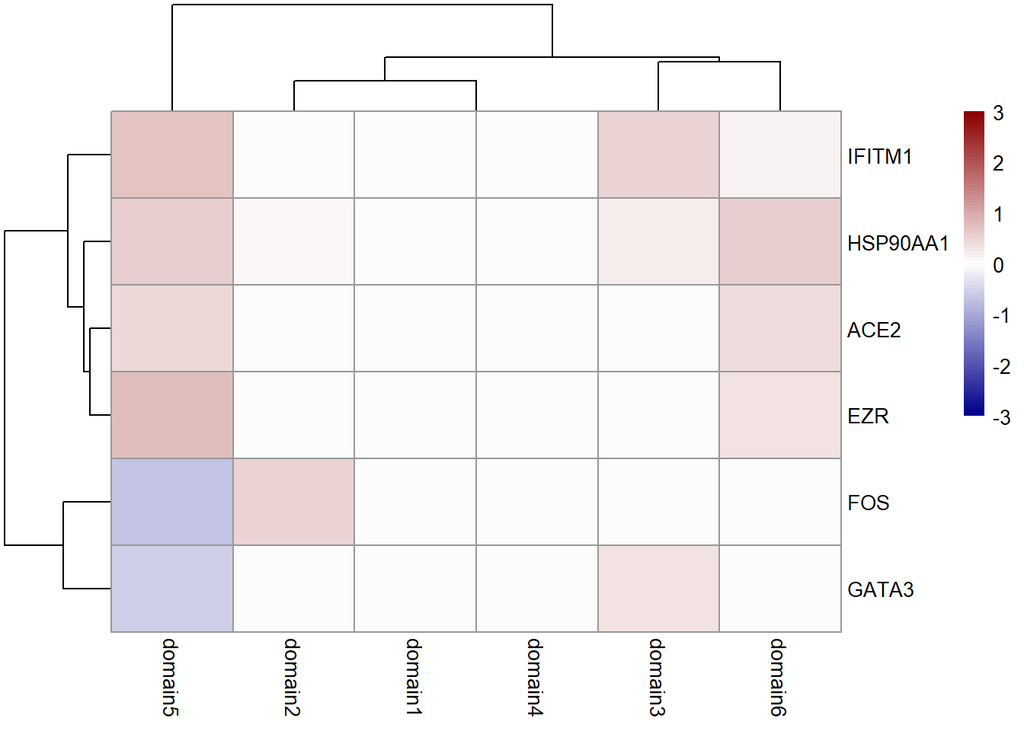

```r
pheatmap(res$means,
         breaks = seq(-3,3,length.out = 101),
         col = colorRampPalette(c("darkblue", "white", "darkred"))(100))
```